# Chap10.5-10.6

Mijeong Kim

```r
library(tsibble)
library(tsibbledata)
library(tibble)
library(dplyr)
library(knitr)
library(ggplot2)
library(fpp3)
library(fpp2)
library(seasonal)
library(feasts)
```

## 10.5 Dynamic Harmonic Regression

#### Dynamic Harmonic Regression이 필요한 이유

- **긴 계절 주기(seasonal period)**를 가진 데이터에 적합
  - 예: 일별 데이터 (주기 = 365), 주간 데이터 (주기 ≈ 52), 반시간 데이터 (주기 = 48 이상 다수)
- 기존 **ARIMA/ETS 모델**은 월별(12), 분기별(4) 주기에 최적화되어 있으며,
  - `ETS()`는 주기를 최대 24까지 허용
  - `ARIMA()`는 주기를 최대 350까지 허용하나, **200 이상에서는 메모리 한계 발생**
  - **계절 차분이 지나치게 큰 경우 해석이 어려움**

#### Fourier 항을 활용한 계절성 모델링

- **계절 패턴은 Fourier 항(사인, 코사인)**으로 표현

$$x_{1,t} = \sin\left(\frac{2\pi t}{m}\right), \quad x_{2,t} =
\cos\left(\frac{2\pi t}{m}\right), ...$$
`fourier()` 함수의 `K` 인자는 포함할 **sin, cos 항의 쌍의 개수**를 지정한다. 계절 주기 $m$에 대해, 설정 가능한 최대값은 $K = m / 2$ 이다.

- 데이터의 **단기 변화는 ARMA 오차**로 처리

#### 📌 장점

- 임의의 주기 길이 사용 가능
- 다중 주기를 가진 데이터에도 적용 가능 (서로 다른 주파수 포함)
- **계절 패턴의 부드러움은 $K$ 값으로 조절** (작을수록 부드러움)
- ARMA 오차로 단기 동역학 쉽게 반영

#### ⚠️ 단점

- 계절 패턴이 **고정되어 있다고 가정** (시간 변화 없음)
  - 하지만 실무에서는 대부분 계절성이 안정적이므로 큰 문제는 아님

### Example: Australian eating out expenditure

- 데이터: **2004 ~ 2018년 월별 카페·레스토랑·테이크아웃 지출 (십억 단위)**
- 목표: 향후 **24개월 예측**
- 계절성 표현: **Fourier 항의 개수 $K = 1$ ~ $K = 6$** 비교
- 결과:
  - $K$ 증가 시 **보다 복잡한(wiggly)** 계절 패턴 반영
  - **ARIMA 모형은 단순화됨**
  - **AICc 기준 최적값은 $K = 6$**
    - 특히 $K = 4$ → $K = 5$에서 AICc 급감

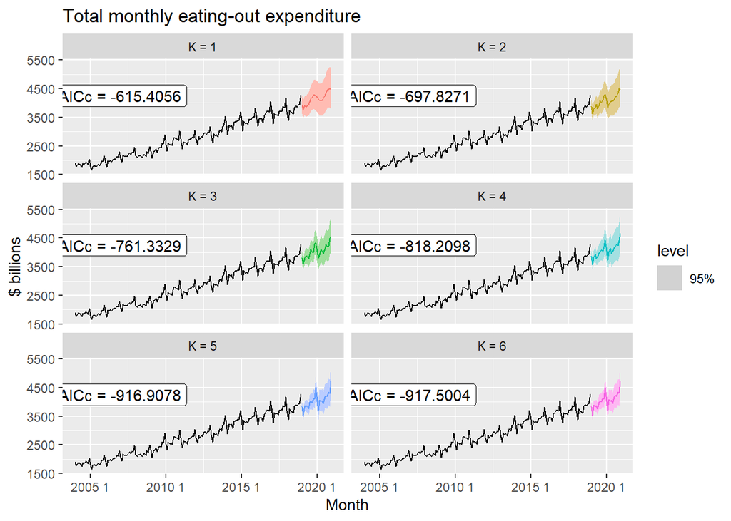

```r
aus_cafe <- aus_retail |>
  filter(
    Industry == "Cafes, restaurants and takeaway food services",
    year(Month) %in% 2004:2018
  ) |>
  summarise(Turnover = sum(Turnover))

fit <- model(aus_cafe,
  `K = 1` = ARIMA(log(Turnover) ~ fourier(K=1) + PDQ(0,0,0)),
  `K = 2` = ARIMA(log(Turnover) ~ fourier(K=2) + PDQ(0,0,0)),
  `K = 3` = ARIMA(log(Turnover) ~ fourier(K=3) + PDQ(0,0,0)),
  `K = 4` = ARIMA(log(Turnover) ~ fourier(K=4) + PDQ(0,0,0)),
  `K = 5` = ARIMA(log(Turnover) ~ fourier(K=5) + PDQ(0,0,0)),
  `K = 6` = ARIMA(log(Turnover) ~ fourier(K=6) + PDQ(0,0,0))
)

fit |>
  forecast(h = "2 years") |>
  autoplot(aus_cafe, level = 95) +
  facet_wrap(vars(.model), ncol = 2) +
  guides(colour = "none", fill = "none", level = "none") +
  geom_label(
    aes(x = yearmonth("2007 Jan"), y = 4250,
        label = paste0("AICc = ", format(AICc))),
    data = glance(fit)
  ) +
  labs(title= "Total monthly eating-out expenditure",
       y="$ billions")
```

Figure 10.11: Using Fourier terms and ARIMA errors for forecasting monthly expenditure on eating out in Australia.

## 10.6 Lagged predictors

#### 지연된 예측 변수(Lagged Predictors)의 필요성

- 일부 예측 변수의 영향은 **즉각적이지 않고 시차를 두고 발생**함
- 예시:
  - 광고 캠페인은 종료 후에도 일정 기간 판매에 영향
  - 안전 정책 변경은 초기에는 사고를 줄이지만, 시간이 지남에 따라 효과가 감소

#### 지연 효과를 반영한 회귀모형

- 예측 변수 $x_t$가 지연 영향을 갖는 경우, 다음과 같은 모형 사용:

$$y_t = \beta_0 + \gamma_0 x_t + \gamma_1 x_{t-1} + \cdots + \gamma_k
x_{t-k} + \eta_t$$

- 여기서 $\eta_t$는 **ARIMA 오차 항**
- **지연 차수 $k$**, 그리고 ARIMA 오차의 $p, q$는 **AICc 기준으로 선택**

### Example: TV advertising and insurance quotations

- 데이터: **2002년 1월 ~ 2005년 4월**, 미국 보험사의 월별 광고비 및 보험 견적 수
- 목적: **광고 지출이 견적 요청 수에 미치는 지연 효과 분석**
- **그림 10.12**는 두 변수의 시계열을 시각적으로 보여줌

```r
library(tsibble)
library(tibble)
library(zoo)        # for as.yearmon
library(lubridate)  # optional, for date handling

# 1. 시간 정보 추출 (yearmon 형식)
time_index <- as.yearmon(time(insurance))

# 2. tsibble이 지원하는 yearmonth 형식으로 변환
time_index <- yearmonth(time_index)  # <- 여기 추가

# 3. 데이터프레임화 및 시간 열 추가
insurance_df <- as.data.frame(insurance)
names(insurance_df)<-c("Quotes",   "TVadverts")
insurance_df <- tibble::tibble(
  Month = time_index,
  insurance_df
)

# 4. tsibble로 변환
insurance_tsbl <- as_tsibble(insurance_df, index = Month)

# 확인
print(insurance_tsbl)
```

```
## # A tsibble: 40 x 3 [1M]
##      Month Quotes TVadverts
##      <mth>  <dbl>     <dbl>
##  1  2002 1   13.0      7.21
##  2  2002 2   15.4      9.44
##  3  2002 3   13.2      7.53
##  4  2002 4   13.0      7.21
##  5  2002 5   15.4      9.44
##  6  2002 6   11.7      6.42
##  7  2002 7   10.1      5.81
##  8  2002 8   10.8      6.20
##  9  2002 9   13.3      7.59
## 10 2002 10   14.6      8.00
## # ℹ 30 more rows
```

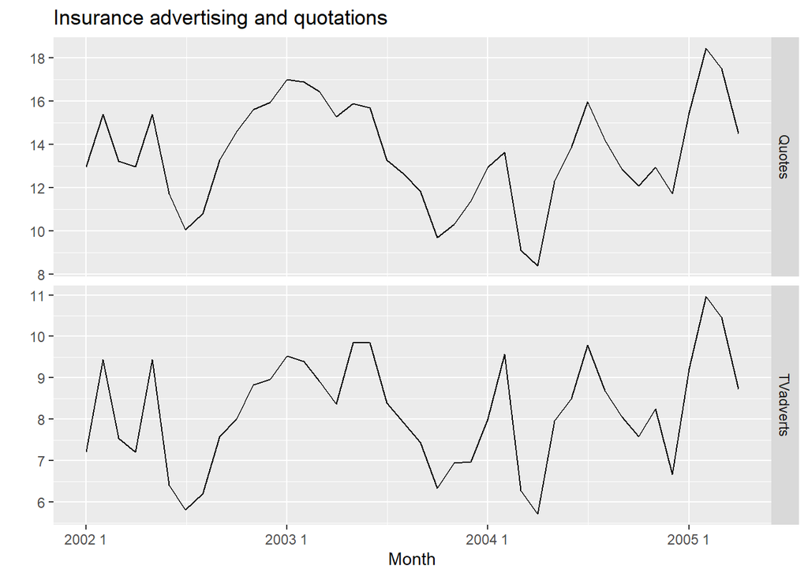

```r
insurance<-insurance_tsbl
insurance |>
  pivot_longer(Quotes:TVadverts) |>
  ggplot(aes(x = Month, y = value)) +
  geom_line() +
  facet_grid(vars(name), scales = "free_y") +
  labs(y = "", title = "Insurance advertising and quotations")
```

Figure 10.12: Numbers of insurance quotations provided per month and the expenditure on advertising per month.

모델 비교를 위해 광고비 지출 데이터를 현재 달부터 최대 3개월 전까지 포함하도록 설정하며, 모든 모델이 동일한 학습 데이터를 사용하도록 처음 3개월을 제외하고 학습을 시작한다.

```r
fit <- insurance |>
  # Restrict data so models use same fitting period
  mutate(Quotes = c(NA, NA, NA, Quotes[4:40])) |>
  # Estimate models
  model(
    lag0 = ARIMA(Quotes ~ pdq(d = 0) + TVadverts),
    lag1 = ARIMA(Quotes ~ pdq(d = 0) +
                 TVadverts + lag(TVadverts)),
    lag2 = ARIMA(Quotes ~ pdq(d = 0) +
                 TVadverts + lag(TVadverts) +
                 lag(TVadverts, 2)),
    lag3 = ARIMA(Quotes ~ pdq(d = 0) +
                 TVadverts + lag(TVadverts) +
                 lag(TVadverts, 2) + lag(TVadverts, 3))
  )
```

다음으로 AICc 기준에 따라 광고 지출의 최적 시차 길이를 선택한다.

```r
glance(fit)
```

```
## # A tibble: 4 × 8
##   .model sigma2 log_lik   AIC  AICc   BIC ar_roots  ma_roots
##   <chr>   <dbl>   <dbl> <dbl> <dbl> <dbl> <list>    <list>
## 1 lag0    0.265   -28.3  66.6  68.3  75.0 <cpl [2]> <cpl [0]>
## 2 lag1    0.209   -24.0  58.1  59.9  66.5 <cpl [1]> <cpl [1]>
## 3 lag2    0.215   -24.0  60.0  62.6  70.2 <cpl [1]> <cpl [1]>
## 4 lag3    0.206   -22.2  60.3  65.0  73.8 <cpl [1]> <cpl [1]>
```

AICc 기준 최적 모델은 현재 달과 이전 달의 광고 지출을 포함하는 두 개의 예측 변수를 가진 lag1 모델이다. 이제 이 모델을 전체 데이터를 사용해 다시 추정한다.

```r
fit_best <- insurance |>
  model(ARIMA(Quotes ~ pdq(d = 0) +
              TVadverts + lag(TVadverts)))
report(fit_best)
```

```
## Series: Quotes
## Model: LM w/ ARIMA(1,0,2) errors
##
## Coefficients:
##          ar1     ma1     ma2  TVadverts  lag(TVadverts)  intercept
##       0.5123  0.9169  0.4591     1.2527          0.1464     2.1554
## s.e.  0.1849  0.2051  0.1895     0.0588          0.0531     0.8595
##
## sigma^2 estimated as 0.2166:  log likelihood=-23.94
## AIC=61.88   AICc=65.38   BIC=73.7
```

#### 최종 선택된 모델과 예측

선택된 모델은 오차항이 ARIMA(1,0,2) 구조를 가지며, 다음과 같이 표현된다:

$$y_t = 2.155 + 1.253x_t + 0.146x_{t-1} + \eta_t$$

여기서  
- $y_t$: t월의 견적 수  
- $x_t$: t월의 광고비  
- $\eta_t = 0.512\eta_{t-1} + \varepsilon_t + 0.917\varepsilon_{t-1} + 0.459\varepsilon_{t-2}$  
- $\varepsilon_t$: 백색잡음

앞으로의 광고비를 월 8단위로 설정하면, 이 모델을 사용하여 예측값을 계산할 수 있다. 아래는 해당 광고비 가정 하에서의 예측 결과(Figure 10.13 참조)이다.

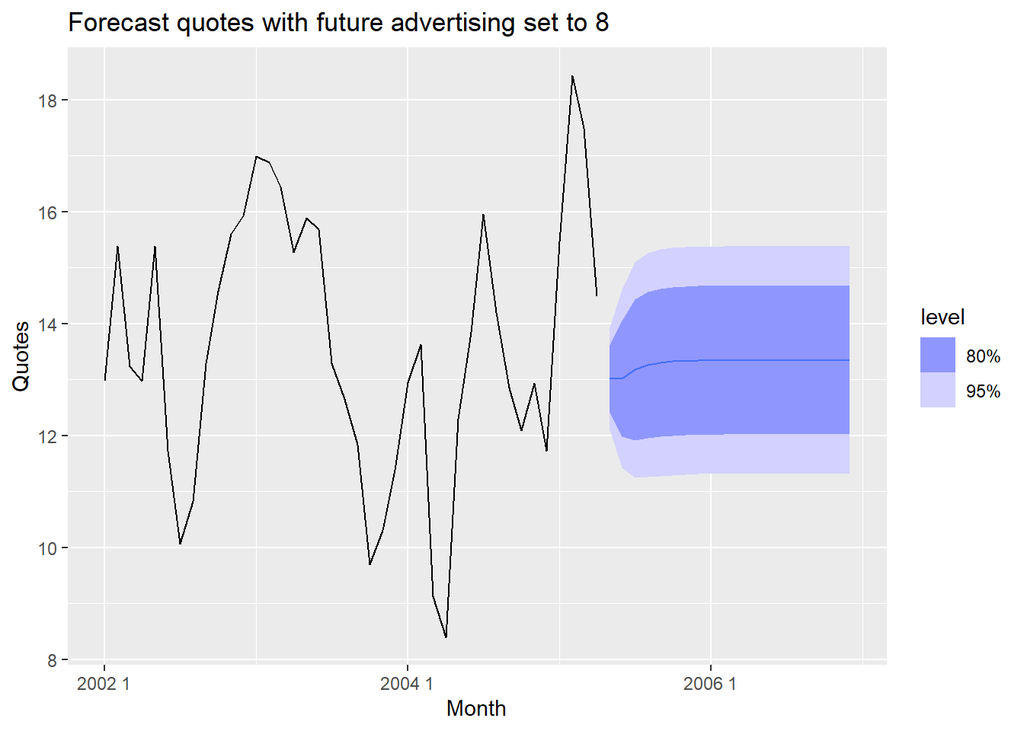

```r
insurance_future <- new_data(insurance, 20) |>
  mutate(TVadverts = 8)
fit_best |>
  forecast(insurance_future) |>
  autoplot(insurance) +
  labs(
    y = "Quotes",
    title = "Forecast quotes with future advertising set to 8"
  )
```

Figure 10.13: Forecasts of monthly insurance quotes, assuming that the future advertising expenditure is 8 units in each future month.